# Clonalscope (Spatial Transcriptomic)

Chi-Yun Wu, Zhang Lab, University of Pennsylvania

## Description

Clonalscope enables subclone detection, malignant spot labeling (with matched WGS/WES data), and lineage tracing in spatial transcriptomic data.

For more information about the method, please check out the [github](https://github.com/seasoncloud/Clonalscope) and the manuscript.

## Prepare input files

The following are the input files for different steps.

1. A feature-barcode (sparse) UMI matrix. [EXAMPLE for 1-3](https://cf.10xgenomics.com/samples/spatial-exp/1.1.0/V1_Breast_Cancer_Block_A_Section_2/V1_Breast_Cancer_Block_A_Section_2_filtered_feature_bc_matrix.tar.gz)
- The matrix is the standard output of the Space Ranger software.
- Each element is the number of UMIs associated with a feature (row) and a barcode (column).
2. A tsv file for all cell barcodes.
- The “barcodes.tsv” file is the standard output of the Space Ranger software.
- Each row is a barcode indicating cell identity.
3. A tsv file for feature information.
- The “features.tsv” file is the standard output of the Space Ranger software.
- Each row is a gene.The first two columns need to be gene ID and gene name.
4. A matrix for cell type annotation. [EXAMPLE](https://github.com/seasoncloud/Clonalscope/blob/main/data-raw/P5931/scRNA/celltype_all.rds)
- Each row is a cell. The first and second columns are “cell barcodes” and “annotated cell types”.
- This matrix is used to specify the cells to use as the baseline for coverage normalization. Please specify the set of cells to be used as the baseline as “normal”.
5. Read count matrices from matched tumor and normal WGS/WES data. (Optional) [EXAMPLE](https://github.com/seasoncloud/Clonalscope/tree/main/data-raw/P5931/WGS)
- Each row is a bin. The values in the matrices represent total read counts for each bin.
- The matrix has one column showing the summed read counts for each bin.
- The row names should be ordered and in the format of “chr-start-end” such as chr1-1-20000.
- Without paired normal sample, other normal samples aligned to the same reference genome (eg. GRCh38) also work if with matched bins.
- Without matched tumor and normal WGS/WES data, chromosome arms can be used as the segments.

## Tutorial for Spatial transcriptomic data

#### Step0. Load the input files

- In R, set up the environment and read common files

```
library(Clonalscope) # load the library
setwd("~/Clonalscope/") # set path to the github folder

dir_path <- "./samples/BC_ductal2/ST/output/"; dir.create(dir_path) # set up output directory

# Size of each chromosome (hg19 and GRCh38 are provided.)
size=read.table("data-raw/sizes.cellranger-GRCh38-1.0.0.txt", stringsAsFactors = F)

# List of cyclegenes retrieved from the "CopyKAT"package (https://github.com/navinlabcode/copykat)
cyclegenes=readRDS("data-raw/cyclegenes.rds")

# bed file indicating gene positions (hg19 and GRCh38 are provided.)
bed=read.table("data-raw/hg38.genes.bed", sep='\t', header = T)
```

- Read example files

```
# files for scRNA-seq data
mtx=readMM("data-raw/BC_ductal2/ST/filtered_feature_bc_matrix/matrix.mtx.gz")
barcodes=read.table("data-raw/BC_ductal2/ST/filtered_feature_bc_matrix/barcodes.tsv.gz", stringsAsFactors = F, sep='\t', header=F)
features=read.table("data-raw/BC_ductal2/ST/filtered_feature_bc_matrix/features.tsv.gz", stringsAsFactors = F, sep='\t', header=F)
celltype0=readRDS("data-raw/BC_ductal2/ST/celltype_all.rds")
```

#### Step1. Segment the genome using matched WGS/WES data (Optional)

- In this step, prior segments and CNA states are retrieved from matched WGS/WES data for the downstream analysis.
- Chromosome arms are used as the segments here without mathced WGS/WES data.

```
# Generate segmentation table for each chromosome arm.
chrarm=read.table("data-raw/cytoarm_table_hg38.txt", stringsAsFactors = F, sep='\t', header=T)
chrarm=chrarm[order(as.numeric(chrarm[,1]),as.numeric(chrarm[,3])),]
bin_bed=chrarm[,-2]

seg_table_filtered=data.frame("chr"=bin_bed[,1], 'start'=as.numeric(bin_bed[,2]),
'end'=as.numeric(bin_bed[,3]), 'states'=1, 'length'=as.numeric(bin_bed[,3])-as.numeric(bin_bed[,2]),
'mean'=0, 'var'=0, 'Var1'=1:nrow(bin_bed),'Freq'=50000,
'chrr'=paste0(bin_bed[,1],":", bin_bed[,2]), stringsAsFactors = F)
```

- For segmentation with matched WGS/WES data, please see example codes in [Step.1](https://github.com/seasoncloud/Clonalscope/tree/main/samples/P5931/scRNA)

#### Step2. Subclone detection in spatial transcriptomic data

- In Step2, copy number states of each region are estimated for each spot in the spatial transcriptomic dataset with the prior information from bulk WGS/WES data. Then subclones based on copy number configurations are detected by a nested Chinese Restaurant Process.
- Filter input files

```
Input_filtered=FilterFeatures(mtx=mtx, barcodes=barcodes, features=features, cyclegenes=cyclegenes)

# Remove raw inputs
rm(mtx); rm(barcodes); rm(features)
```

- Subclone detection in scRNA-seq data

```
set.seed(2022)
Cov_obj=RunCovCluster(mtx=Input_filtered$mtx, barcodes=Input_filtered$barcodes,
                      features=Input_filtered$features, bed=bed,
                      celltype0=celltype0, var_pt=0.99, var_pt_ctrl=0.99, include='all',
                      alpha_source='all', ctrl_region=NULL,
                      seg_table_filtered=seg_table_filtered, size=size,
                      dir_path=dir_path, breaks=50, prep_mode = 'intersect', seed=200)
# save the object
saveRDS(Cov_obj,paste0(dir_path,"/Cov_obj.rds"))
```

#### Step3. Visualization

- Extract clustering results from the object.

```
clustering= Cov_obj$result_final$clustering
clustering2= Cov_obj$result_final$clustering2
result=Cov_obj$result_final$result
Zest=result$Zest
table(result$Zest)
```

- If you want to adjust the resolution (ie. minimum number of cells/spots in each cluster), the following command can be re-run with different “mincell” values. Larger values will result in less clusters.

```
#result=AssignCluster(clustering2, mincell = 100)
#Zest=result$Zest
#table(result$Zest)
```

- Visualize the subclones/clusters in the heatmap.

```
PlotClusters(df = clustering$data, celltype = celltype0, Assign_obj =result, mode = "genome",  fontsize = 7, lab_mode=FALSE)
```

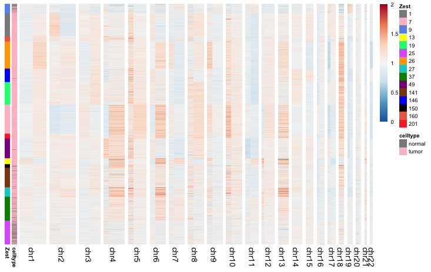

- Visuzlize the subclones/clusters in the UMAP.

```
# Plot the UMAP and save the coordinates
set.seed(2022)
emb=PlotUMAP(df = clustering$data, celltype = celltype0, Assign_obj =result, mode = "Zest")
```

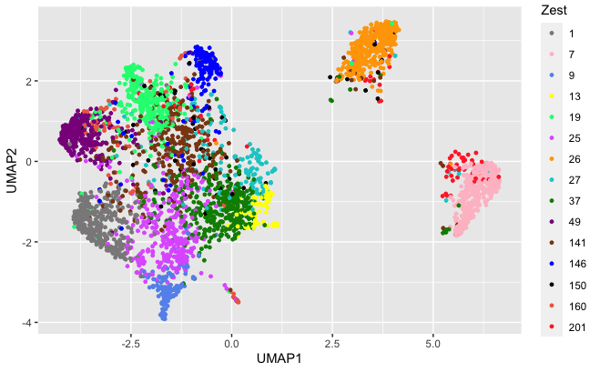

#### Step4. Integrate with Spatial information (Optional)

- Load the h5 file (Standard Space Ranger output) as a Seurat object.
- The h5 file for the human breast tumor dataset can be found [here](https://cf.10xgenomics.com/samples/spatial-exp/1.1.0/V1_Breast_Cancer_Block_A_Section_2/V1_Breast_Cancer_Block_A_Section_2_filtered_feature_bc_matrix.h5)

```
library(Seurat)
vs <- Load10X_Spatial("data-raw/BC_ductal2/ST/",
filename = "V1_Breast_Cancer_Block_A_Section_2_filtered_feature_bc_matrix.h5")
```

- Set the color the same as those in Clonalscope.

```
library(gplots)
cols=col2hex(colors()[c(1,609, 536, 62, 652, 611, 463, 498, 71,
258, 84, 56, 26, 154, 59, 134, 78, 116, 85, 20, 259)])
```

- Visualize subclones in the H&E image.

```
clusters=Zest[match(names(vs$orig.ident), names(Zest))]; clusters[is.na(clusters)]=0
Idents(vs)=factor(clusters, levels=sort(as.numeric(unique(clusters))))
SpatialDimPlot(vs, label = F, label.size = 3, stroke = 0, pt.size.factor = 2, cols=cols)
```

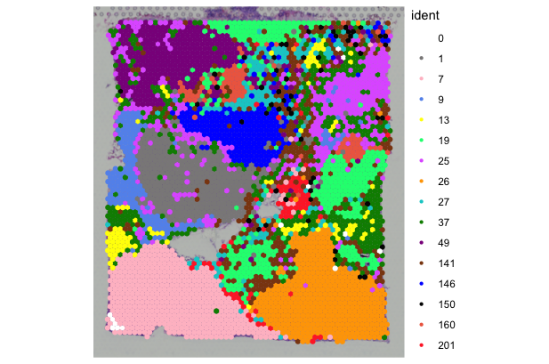

## Citation

Wu, C.-Y. et al. Cancer subclone detection based on DNA copy number in single cell and spatial omic sequencing data. *bioRxiv* (2022):

[Back to the main page](https://github.com/seasoncloud/Clonalscope)